# Lecture 34: Arnoldi for eigenvalues

The convergence of the Ritz values (eigenvalues of $H_n$) to the eigenvalues of $A$ is very complicated in general. As a rule, though, the iteration tends to find outlying or extreme eigenvalues first, only gradually resolving the interior ones.

Here is a matrix with random eigenvalues of magnitude about 15 or less, plus two prescribed eigenvalues lying a little outside that disk.

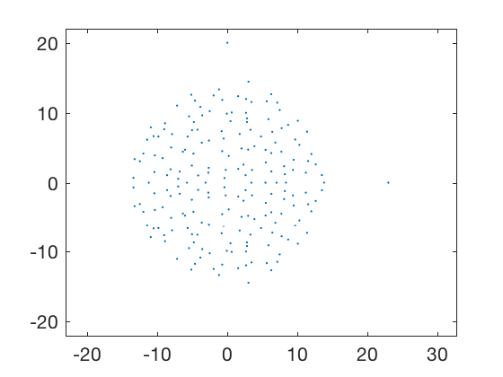

```matlab
m = 200;
rng(231)
A = [ randn(m-2,m-2), zeros(m-2,2); zeros(2,m-2), diag([23,20i]) ];
b = randn(m,1);  b = b/norm(b);
plot(eig(A),'.')
axis([-22 22 -22 22]), axis equal
```

Here we compute the Arnolid iteration. Every so often we plot the eigenvalues of $H_n$, plus the "Arnoldi lemniscate" defined as

$$\left\{ z\in\mathbb{C}: \bigl|p^n(z)\bigr| = \frac{\|p^n(A)b\|}{\|b\|} \right\},$$

where $p^n(A)$ is the characteristic polynomial of $H_n$ (and the solution to a minimization problem for $A$ as described in the text). The interior of this curve is more or less what the iteration perceives as the spectrum of $A$.

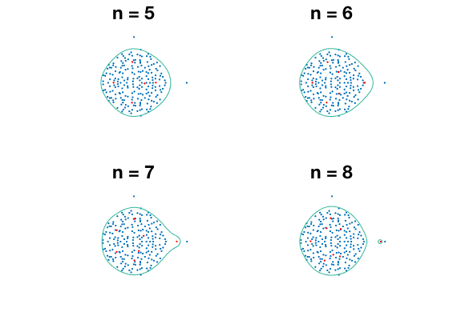

```matlab
[Q,H] = arnoldi(A,b,24);

[X,Y] = meshgrid(linspace(-25,25,100));
Z = X + 1i*Y;

plt = 1;
for n = 5:8
    subplot(2,2,plt)
    plot(eig(A),'.')
    axis([-25 25 -25 25]), axis equal
    hold on

    Hn = H(1:n,1:n);
    plot(eig(Hn),'r.')
    pn = poly(Hn);
    c = norm(polyvalm(pn,A)*b);
    W = polyval(pn,Z);
    contour(X,Y,abs(W),c*[1 1])
    title(sprintf('n = %i',n))
    axis off
    plt = plt+1;
end
```

You can see how the lemniscate bulges out to include the most extreme eigenvalue, then pinches off once it is located. The next to be found is the upper outlier.

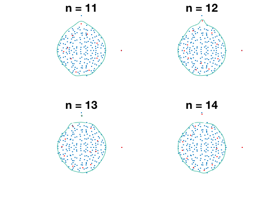

```matlab
plt = 1;
for n = 11:14
    subplot(2,2,plt)
    plot(eig(A),'.')
    axis([-20 20 -20 20]), axis equal
    hold on

    Hn = H(1:n,1:n);
    plot(eig(Hn),'r.')
    pn = poly(Hn);
    c = norm(polyvalm(pn,A)*b);
    W = polyval(pn,Z);
    contour(X,Y,abs(W),c*[1 1])
    title(sprintf('n = %i',n))
    axis off
    plt = plt+1;
end
```

The convergence to each outlier eigenvalue is roughly linear once they have been located.

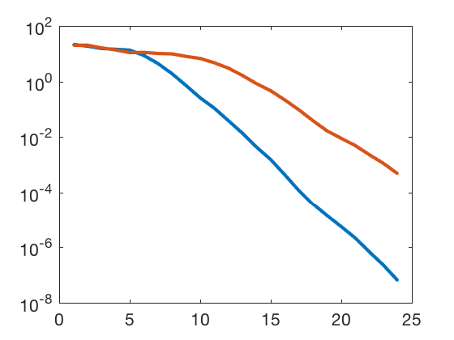

```matlab
for n = 1:24
    Hn = H(1:n,1:n);
    theta = eig(Hn);
    err(n,1) = min(abs(theta-23));
    err(n,2) = min(abs(theta-20i));
end
semilogy(err,'.-')
```

## `eigs`

MATLAB has a built-in function `eigs` to compute eigenvalues by the Arnoldi iteration. It should be used for matrices whose size is larger than a few thousand. We demonstrate it here for a discretized Laplacian.

```matlab
G = numgrid('S',100);
A = delsq(G);
m = length(A)
```

```
m =

        9604
```

```matlab
[V,D] = eigs(A,8);
whos D V
```

```
Name         Size             Bytes  Class     Attributes

  D            8x8                512  double
  V         9604x8             614656  double
```

The resulting output should satisfy $AV=VD$, even though $V$ is not square.

By default the outlying eigenvalues are found first.

```matlab
diag(D)
```

```
ans =

    7.9980
    7.9950
    7.9950
    7.9919
    7.9899
    7.9899
    7.9869
    7.9869
```

However, the algorithm will use shift-and-invert to find eigenvalues closest to any complex number we specify.

```matlab
[V,D] = eigs(A,8,0);  % closest to zero
diag(D)
```

```
ans =

    0.0131
    0.0131
    0.0101
    0.0101
    0.0081
    0.0050
    0.0050
    0.0020
```

## Nonnormality

For most purposes, a normal matrix can be idealized as a collection of scalars in an orthogonal basis. A nonnormal matrix is qualitatively more complicated. They may have very badly conditioned eigenvalues and complicate the estimation of eigenvalues by power and Arnoldi iterations.

For instance, matrices with normal random entries tend to be close to normal. However, triangular random matrices are not.

```matlab
A = randn(50,50);   % close to normal
mu = max(abs(eig(A)));
A = A / (1.03*mu);  % ensure spectral radius < 1
[V,D] = eig(A);
cond(V)

B = triu(A);
mu = max(abs(diag(B)));
B = B / (1.03*mu);  % ensure spectral radius < 1
[V,D] = eig(B);
cond(V)
```

```
ans =

   62.9529


ans =

   5.7082e+19
```

The sensitivity of eigenvalues to perturbations is dramatically different in the two cases.

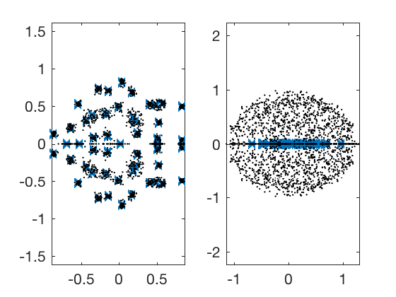

```matlab
clf
M = {A,B};
for k = 1:2
    subplot(1,2,k);
    lam = eig(M{k});
    plot(real(lam),imag(lam),'x')
    hold on, axis equal
    for i = 1:40
        plot(eig(M{k}+0.01*randn(50)),'k.')
    end
end
```

There are many other consequences to nonnormality. For example, the norms of powers of a matrix are asymptotically governed by the spectral radius (largest absolute value of the spectrum). In the normal case, the relationship holds for all time, but in the nonnormal case there can be an arbitrarily long transient behavior that is totally different.

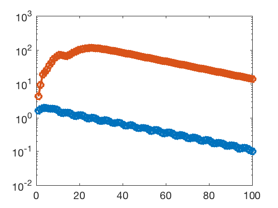

```matlab
clf
nrm = [];
for k = 1:2
    for n = 1:100
      nrm(n,k) = norm(M{k}^n);
    end
end

semilogy(nrm,'-o')
```

For much more about these matters, look at *Spectra and Pseudospectra* by Trefethen and Embree.